# Candy Production Forecasting v.HTMLNote

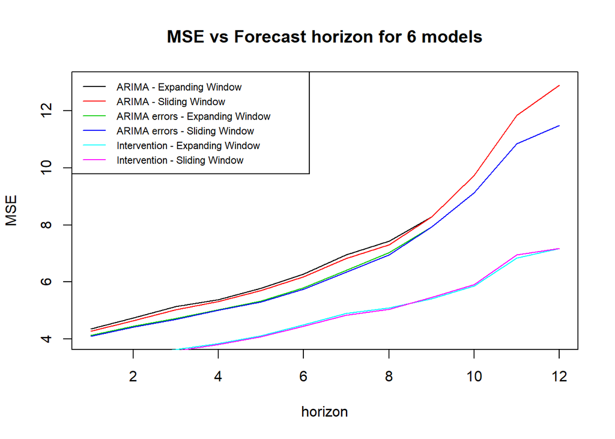

```r
# Plot MSE vs Forecast horizon
win.graph(width=6, height=4.5,pointsize=12)
plot(1:12, colMeans(mse_1,na.rm=TRUE), type="l",col=1,xlab="horizon", ylab="MSE",
     ylim=c(4,13), main="MSE vs Forecast horizon for 6 models")
lines(1:12, colMeans(mse_2,na.rm=TRUE), type="l",col=2)
lines(1:12, colMeans(mse_3,na.rm=TRUE), type="l",col=3)
lines(1:12, colMeans(mse_4,na.rm=TRUE), type="l",col=4)
lines(1:12, colMeans(mse_5,na.rm=TRUE), type="l",col=5)
lines(1:12, colMeans(mse_6,na.rm=TRUE), type="l",col=6)
legend("topleft",legend=c("ARIMA - Expanding Window","ARIMA - Sliding Window",
                          "ARIMA errors - Expanding Window", "ARIMA errors - Sliding Window",
                          "Intervention - Expanding Window","Intervention - Sliding Window"),col=1:6,lty=1,
       cex=0.7, pt.cex = 1)
```

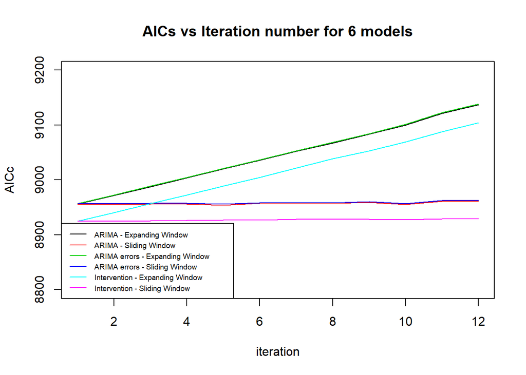

```r
# Plot AICc vs Iteration number
win.graph(width=6, height=4.5,pointsize=12)
plot(1:12, rowMeans(aicc_1,na.rm=TRUE), type="l",col=1,xlab="iteration", ylab="AICc",
     ylim=c(8800,9200), main="AICs vs Iteration number for 6 models")
lines(1:12, rowMeans(aicc_2,na.rm=TRUE), type="l",col=2)
lines(1:12, rowMeans(aicc_3,na.rm=TRUE), type="l",col=3)
lines(1:12, rowMeans(aicc_4,na.rm=TRUE), type="l",col=4)
lines(1:12, rowMeans(aicc_5,na.rm=TRUE), type="l",col=5)
lines(1:12, rowMeans(aicc_6,na.rm=TRUE), type="l",col=6)
legend("bottomleft",legend=c("ARIMA - Expanding Window","ARIMA - Sliding Window",
                          "ARIMA errors - Expanding Window", "ARIMA errors - Sliding Window",
                          "Intervention - Expanding Window","Intervention - Sliding Window"),col=1:6,lty=1,
       cex=0.6, pt.cex = 1)
```

```r
# Aggregate average MAE, MSE and AICc for each model
error_table2 <- as.data.frame(rbind(c(round(mean(mape_1, na.rm=TRUE),4),round(mean(mse_1, na.rm=TRUE),4),
                                     round(mean(aicc_1, na.rm=TRUE),4),"YES","YES"),
                                   c(round(mean(mape_2, na.rm=TRUE),4),round(mean(mse_2, na.rm=TRUE),4),
                                     round(mean(aicc_2, na.rm=TRUE),4),"YES","YES"),
                                   c(round(mean(mape_3, na.rm=TRUE),4),round(mean(mse_3, na.rm=TRUE),4),
                                     round(mean(aicc_3, na.rm=TRUE),4),"YES","NO"),
                                   c(round(mean(mape_4, na.rm=TRUE),4),round(mean(mse_4, na.rm=TRUE),4),
                                     round(mean(aicc_4, na.rm=TRUE),4),"YES","NO"),
                                   c(round(mean(mape_5, na.rm=TRUE),4),round(mean(mse_5, na.rm=TRUE),4),
                                     round(mean(aicc_5, na.rm=TRUE),4),"YES","YES"),
                                   c(round(mean(mape_6, na.rm=TRUE),4),round(mean(mse_6, na.rm=TRUE),4),
                                     round(mean(aicc_6, na.rm=TRUE),4),"YES","YES")),
                             row.names = c("ARIMA-Expanding","ARIMA-Sliding",
                          "regr model (ARIMA errs)-Expanding", "regr model (ARIMA errs)-Sliding",
                          "Intervention-Expanding","Intervention-Sliding"))

colnames(error_table2) <- c("MAPE","MSE","AICc/AIC","Residual white noise","Coefficient significance")
error_table_final2 <- rbind(error_table_final,error_table2)
error_table_final2
```

```
                                    MAPE     MSE  AICc/AIC Residual white noise
Arima model                       2.6945 12.8972 8955.7543                  YES
regr model (ARIMA errs)           2.4889 11.4796 8956.8447                  YES
intervention model                1.7881  7.2042 8924.9753                  YES
ARIMA-Expanding                   1.4461  6.0574 9014.5522                  YES
ARIMA-Sliding                     1.4356  5.9741 8956.4162                  YES
regr model (ARIMA errs)-Expanding 1.3759  5.6419 9015.5835                  YES
regr model (ARIMA errs)-Sliding   1.3738  5.6099 8957.5766                  YES
Intervention-Expanding            1.1605  4.1868 8983.7363                  YES
Intervention-Sliding              1.1424  4.1595 8926.4523                  YES
                                  Coefficient significance
Arima model                                            YES
regr model (ARIMA errs)                                 NO
intervention model                                     YES
ARIMA-Expanding                                        YES
ARIMA-Sliding                                          YES
regr model (ARIMA errs)-Expanding                       NO
regr model (ARIMA errs)-Sliding                         NO
Intervention-Expanding                                 YES
Intervention-Sliding                                   YES
```

As we can tell from table above, the MAPE and MSE are greatly reduced by expanding or sliding windows techniques. Meanwhile, the expanding window increases the AICc for the three models while sliding window keep the values almost the same. If our golden standard is still by comparing the AICc value, then intervention model beats all others. The intervention model with sliding window wins other models, with greatly reduced MAPE and MSE but slightly higher AICc.